# ARIMA Forecasting

```r
if (!require("tidyverse")) install.packages("tidyverse")
library(tidyverse)
if (!require("tm")) install.packages("tm")
library(tm)
if (!require("lubridate")) install.packages("lubridate")
library(lubridate)
if (!require("xts")) install.packages("xts")
```

[output not shown]

```r
library(xts)
if (!require("zoo")) install.packages("zoo")
library(zoo)
if (!require("forecast")) install.packages("forecast")
library(forecast)
if (!require("fpp2")) install.packages("fpp2")
library(fpp2)
```

```r
# read in the price data
token_prices <- read_csv("tokenprices.csv")
```

```
## ──────────────────────────────────────────────────────── Delimiter: "," chr
## (2): coin_id, vs_currency dbl (4): ...1, price, total_volume, market_cap dttm
## (1): timestamp
```

```r
token_names <- c("fantom", "spookyswap", "spiritswap", "liquiddriver", "comb-finance", "0xdao",
                 "atlas-cloud", "soul-swap", "geist-finance", "spartacus")

token_prices <- token_prices %>%
  filter(coin_id %in% token_names) %>%
  select(-vs_currency, -...1)

token_prices$timestamp <- as_datetime(token_prices$timestamp, tz = "UTC")

token_prices %>%
  group_by(coin_id) %>%
  slice(which.min(timestamp)) %>%
  arrange(desc(timestamp))
```

```
## # A tibble: 10 × 5
## # Groups:   coin_id [10]
##    timestamp           coin_id         price total_volume  market_cap
##    <dttm>              <chr>           <dbl>        <dbl>       <dbl>
##  1 2022-01-22 05:01:22 0xdao           0.386    22610069.          0
##  2 2022-01-10 04:06:54 atlas-cloud   273.         704715.          0
##  3 2022-01-10 03:03:02 comb-finance   91.7         92255.          0
##  4 2021-11-02 03:00:38 spartacus      77.3       6276685.          0
##  5 2021-10-06 23:02:50 geist-finance  34.6      38057683.          0
##  6 2021-09-24 15:05:12 soul-swap       0.533        1572.          0
##  7 2021-05-24 09:04:20 liquiddriver    3.43       377854.          0
##  8 2021-05-14 05:03:10 spiritswap      0.242      486095.          0
##  9 2021-05-04 12:02:05 spookyswap     13.4       5456550.          0
## 10 2021-03-30 00:25:21 fantom          0.429   143953901. 1099332730.
```

Going to use newest token to determine the testing data

```r
token_prices <- token_prices %>%
  ungroup()

oxdao <- token_prices %>%
  filter(coin_id == "0xdao")

start.date <- oxdao %>%
  slice_min(timestamp) %>%
  pull(timestamp)

test.start <- oxdao$timestamp[length(oxdao)*.7]
test.length <- trunc(length(oxdao$timestamp) * .3)
test.start2 <- 24*21+5
end.date <- token_prices %>%
  slice_max(timestamp) %>%
  pull(timestamp)
```

Now, let’s start doing some work on Fantom data

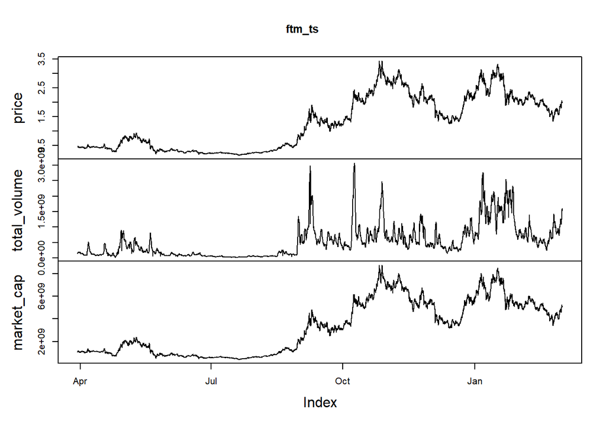

```r
ftm_price <- token_prices %>%
  filter(coin_id == "fantom") %>%
  select(-coin_id) %>%
  arrange(timestamp)

ftm.start.date <- ftm_price %>%
  slice_min(timestamp) %>%
  pull(timestamp)

ftm_ts <- as.xts(ftm_price[,2:4], order.by = ftm_price$timestamp)

plot.zoo(ftm_ts, plot.type = "multiple")
```

Let’s start with using strictly price data and setting up our train-test

```r
train_ftm <- ftm_price %>%
  slice_head(n = length(ftm_price$timestamp) - test.length)
test_ftm <- ftm_price %>%
  slice_tail(n = test.length)
train_ftm <- as.xts(train_ftm[,2], order.by = train_ftm$timestamp)
test_ftm <- as.xts(test_ftm[,2], order.by = test_ftm$timestamp)
```

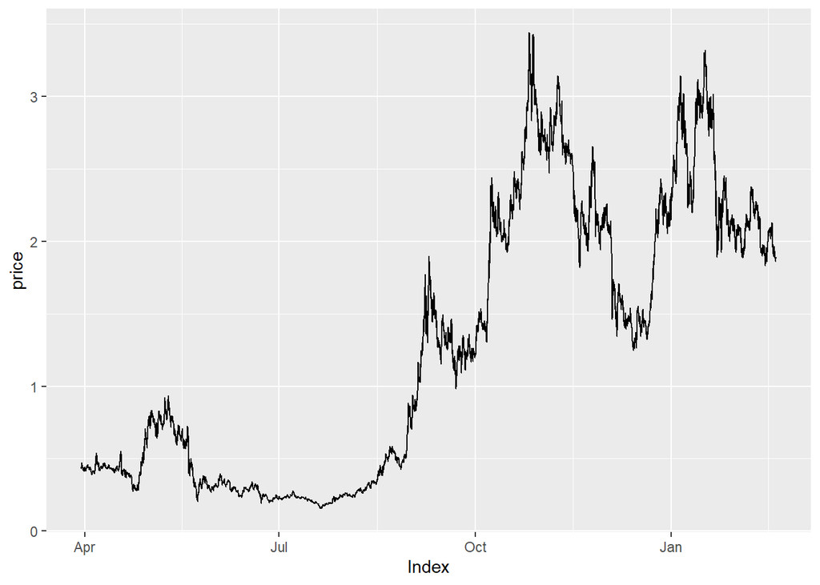

```r
autoplot(train_ftm)
```

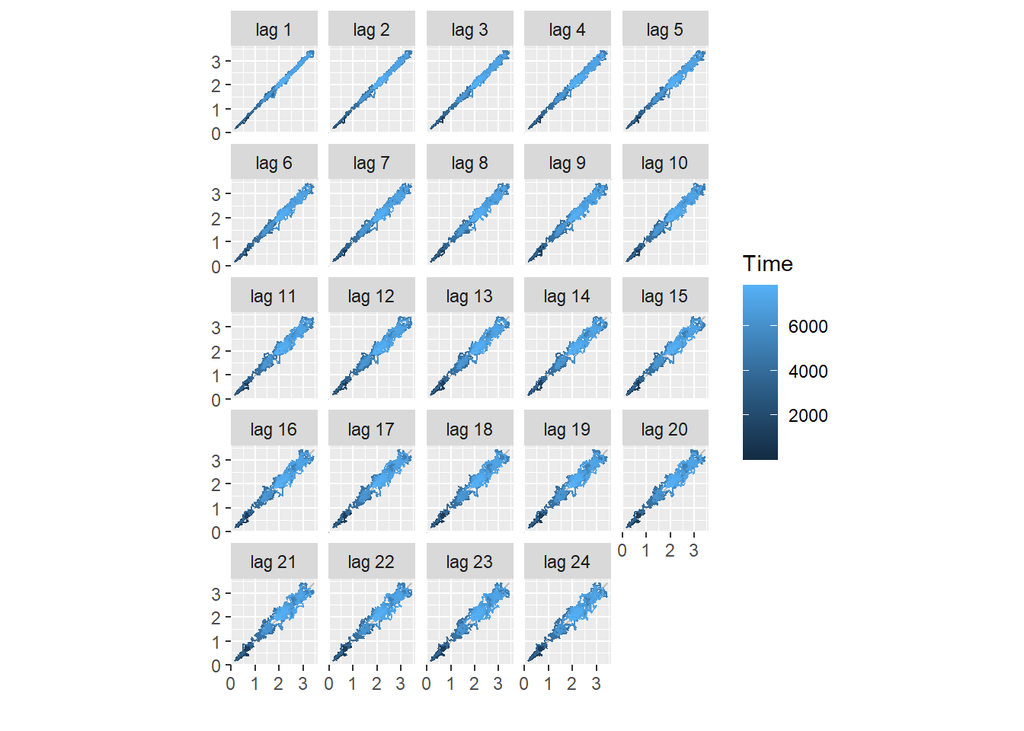

```r
gglagplot(train_ftm, lags = 24)
```

Ljung Box-Test to see if white noise

```r
Box.test(train_ftm, lag = 24, fitdf = 0, type = "Lj")
```

```
##
##  Box-Ljung test
##
## data:  train_ftm
## X-squared = 186030, df = 24, p-value < 2.2e-16
```

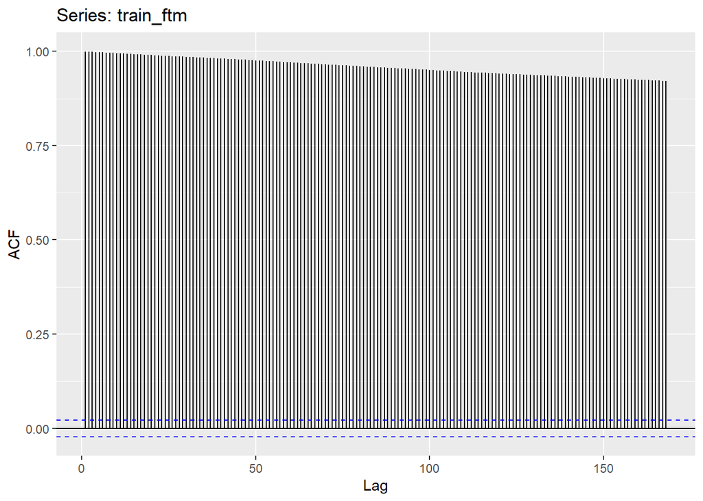

```r
ggAcf(train_ftm, lag.max = 24*7)
```

Definitely not white, noise. Let’s see what differencing does

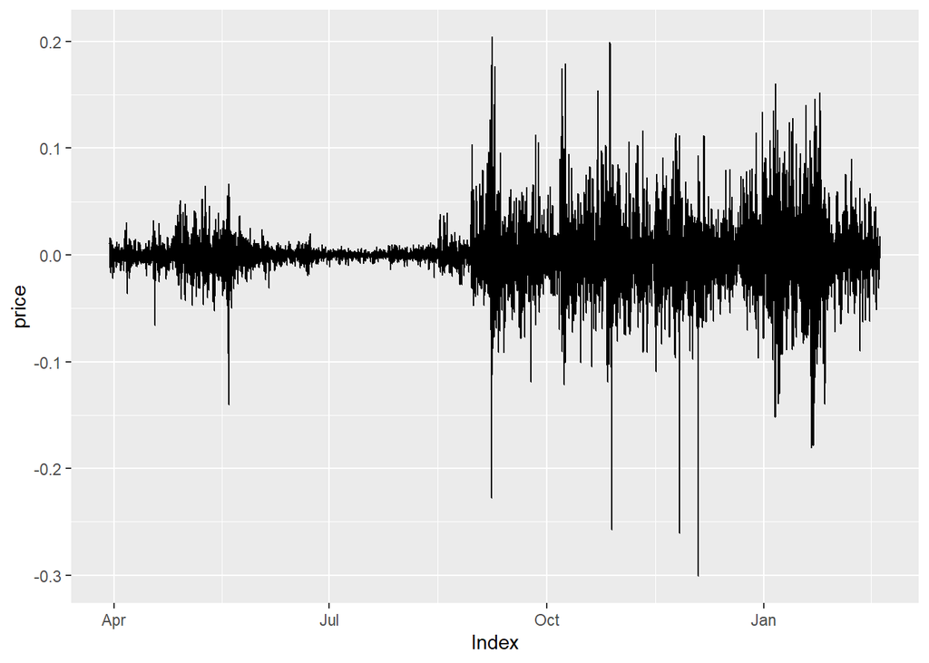

```r
autoplot(diff(train_ftm))
```

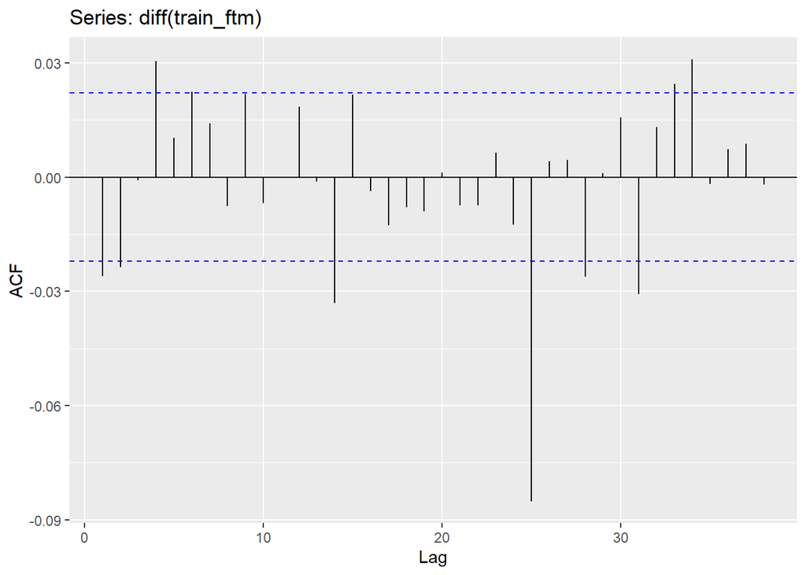

```r
ggAcf(diff(train_ftm))
```

```r
Box.test(diff(train_ftm), lag = 24, fitdf = 0, type = "Lj")
```

```
##
##  Box-Ljung test
##
## data:  diff(train_ftm)
## X-squared = 47.699, df = 24, p-value = 0.00275
```

This still isn’t white noise

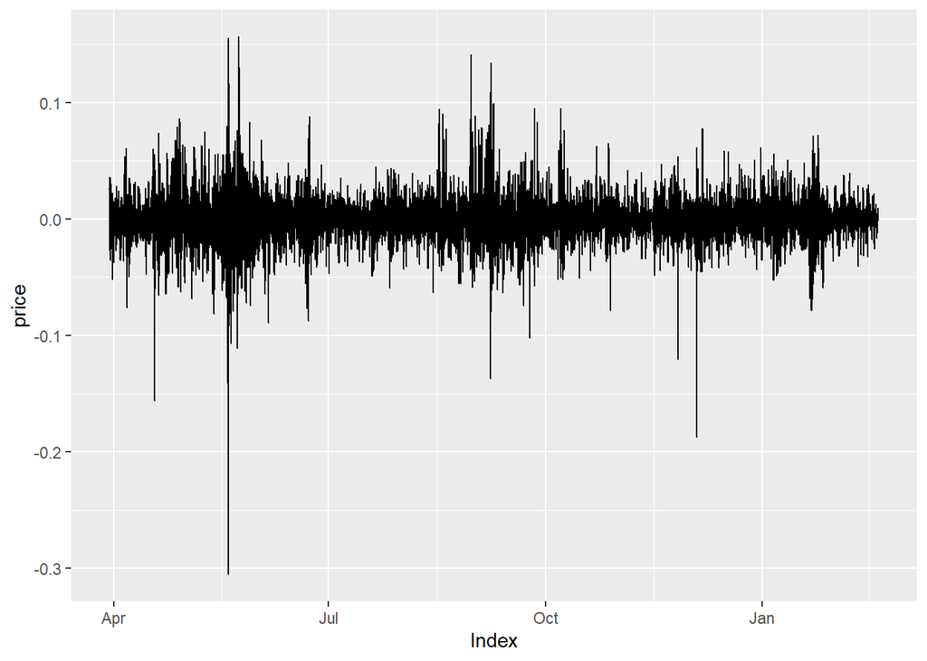

```r
autoplot(diff(log(train_ftm)))
```

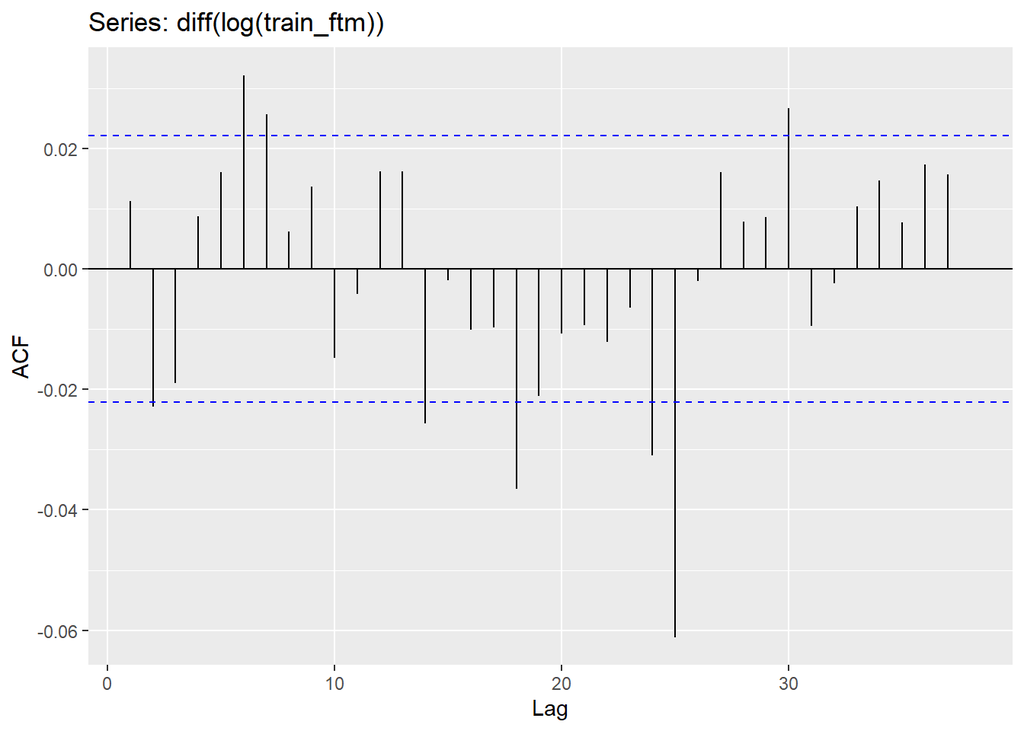

```r
ggAcf(diff(log(train_ftm)))
```

```r
Box.test(diff(log(train_ftm)), lag = 24, fitdf = 0, type = "Lj")
```

```
##
##  Box-Ljung test
##
## data:  diff(log(train_ftm))
## X-squared = 62.843, df = 24, p-value = 2.508e-05
```

That actually made it worse…

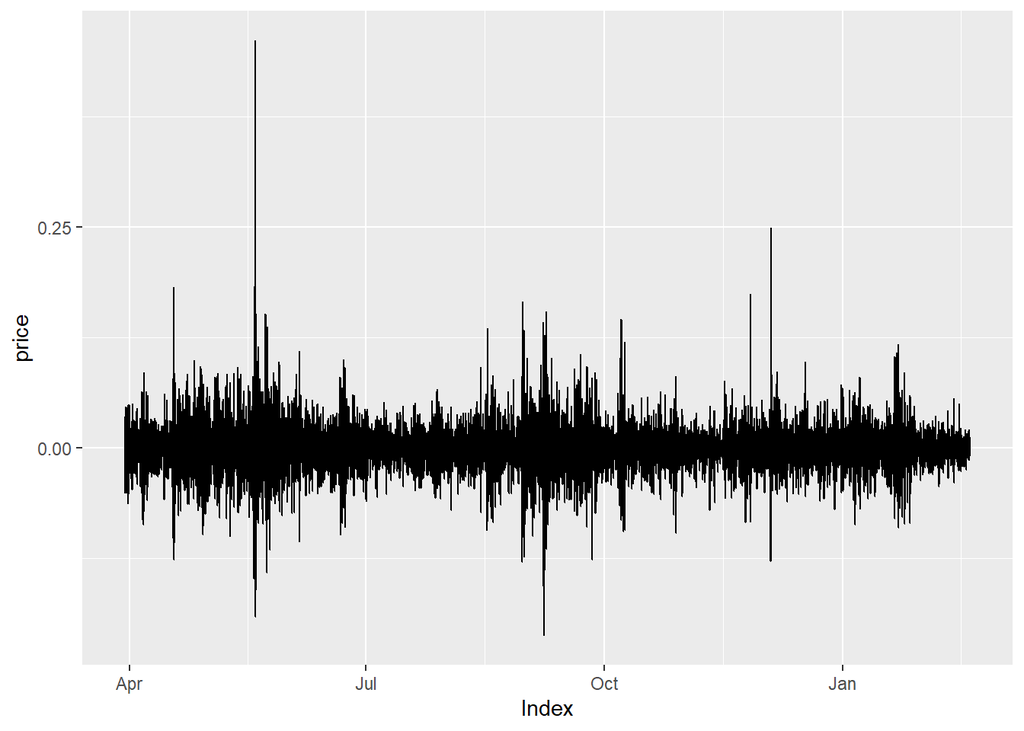

```r
autoplot(diff(diff(log(train_ftm))))
```

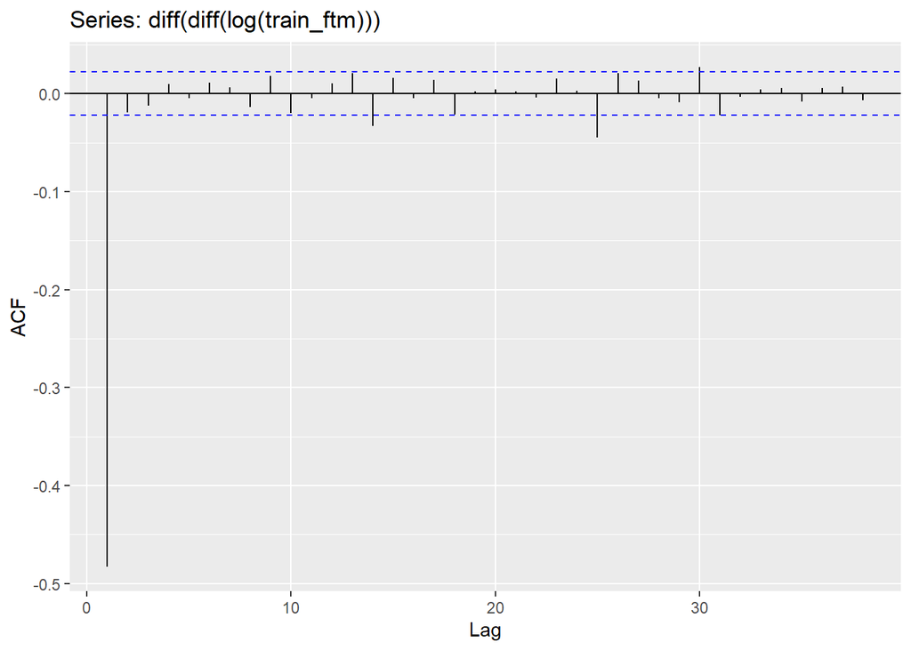

```r
ggAcf(diff(diff(log(train_ftm))))
```

```r
Box.test(diff(diff(log(train_ftm))), lag = 24, fitdf = 0, type = "Lj")
```

```
##
##  Box-Ljung test
##
## data:  diff(diff(log(train_ftm)))
## X-squared = 1860.7, df = 24, p-value < 2.2e-16
```

Let’s try arima models

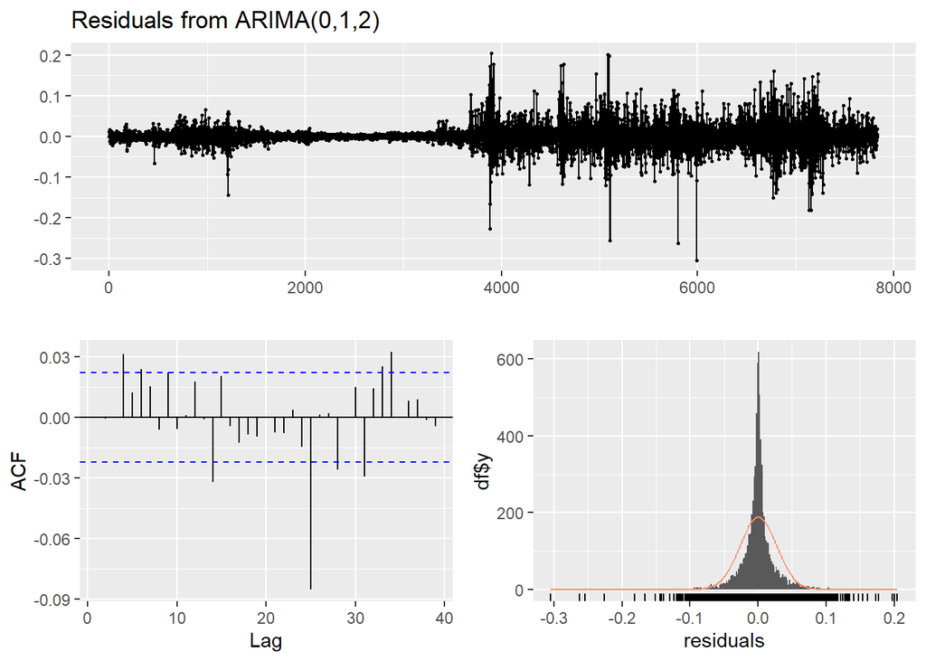

```
##
##  Ljung-Box test
##
## data:  Residuals from ARIMA(0,1,2)
## Q* = 19.389, df = 8, p-value = 0.01291
##
## Model df: 2.   Total lags used: 10
```

```r
arfc_ftm <- auto.arima(train_ftm)
checkresiduals(arfc_ftm)
```

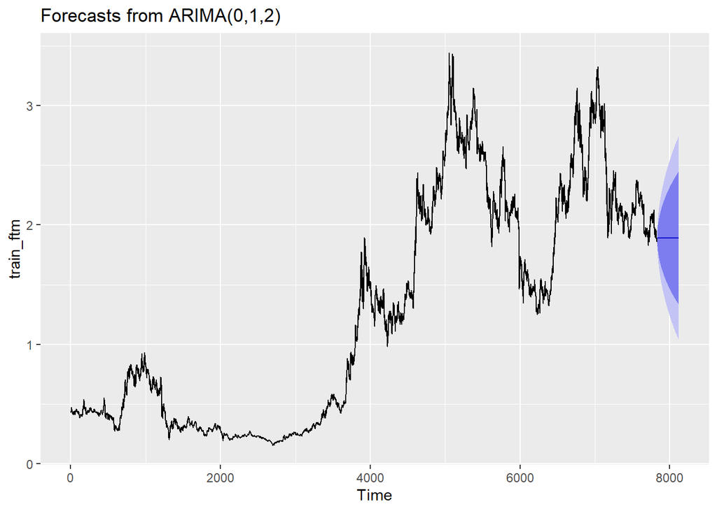

```r
arfc_ftm %>% forecast(h = test.length) %>% autoplot()
```

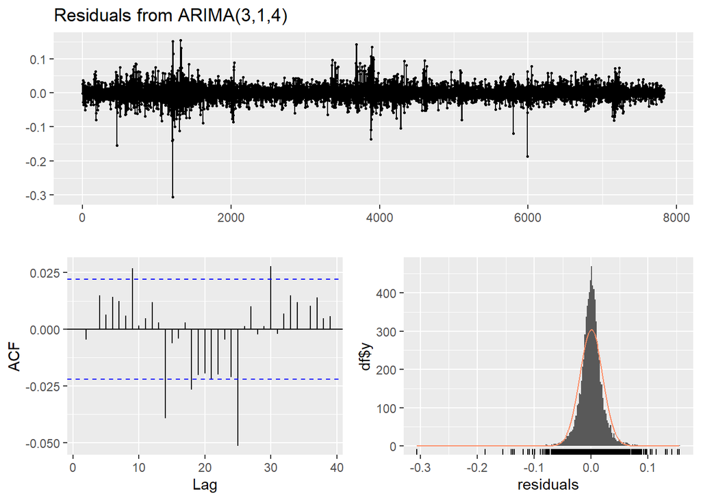

```
##
##  Ljung-Box test
##
## data:  Residuals from ARIMA(3,1,4)
## Q* = 10.948, df = 3, p-value = 0.01201
##
## Model df: 7.   Total lags used: 10
```

```r
arfc_ftm2 <- auto.arima(train_ftm, lambda = 0)
checkresiduals(arfc_ftm2)
```

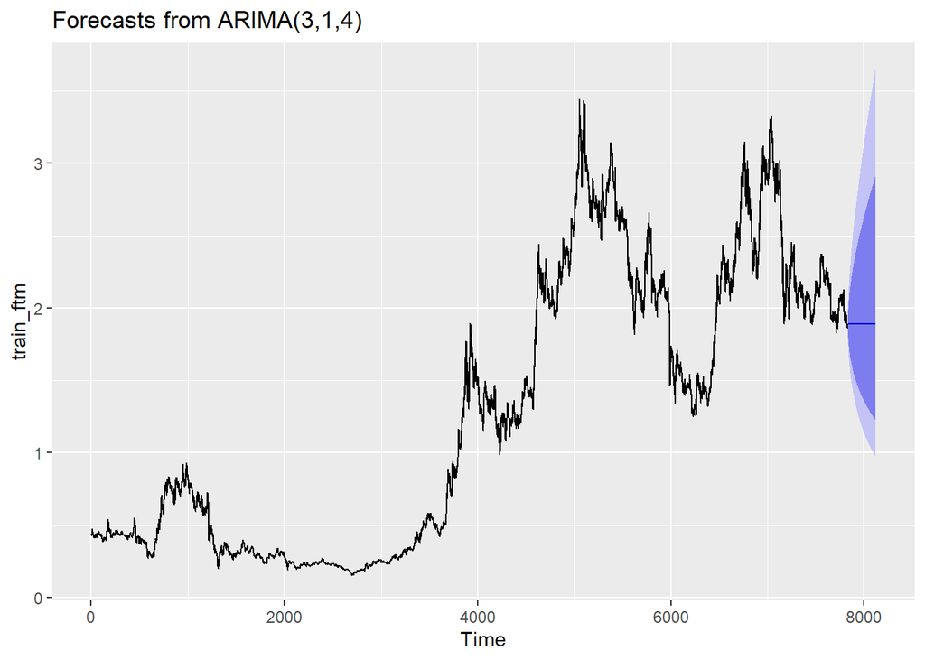

```r
arfc_ftm2 %>% forecast(h = test.length) %>% autoplot()
```

takes longer

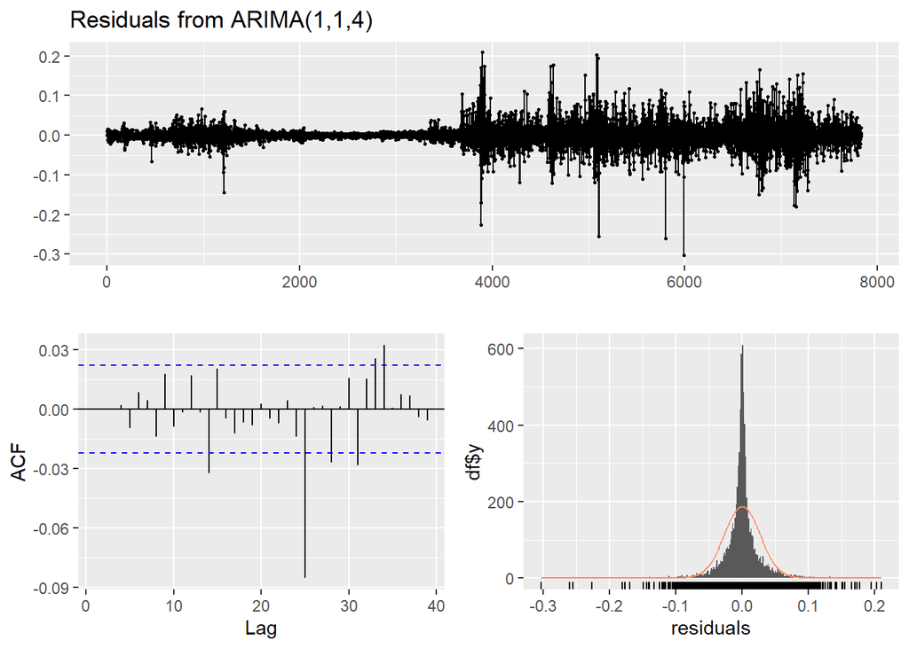

```
##
##  Ljung-Box test
##
## data:  Residuals from ARIMA(1,1,4)
## Q* = 6.0193, df = 5, p-value = 0.3043
##
## Model df: 5.   Total lags used: 10
```

```r
arfc_ftm3 <- auto.arima(train_ftm, stepwise = FALSE)
checkresiduals(arfc_ftm3)
```

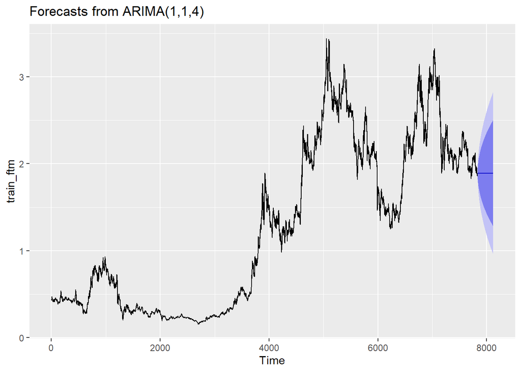

```r
arfc_ftm3 %>% forecast(h = test.length) %>% autoplot()
```

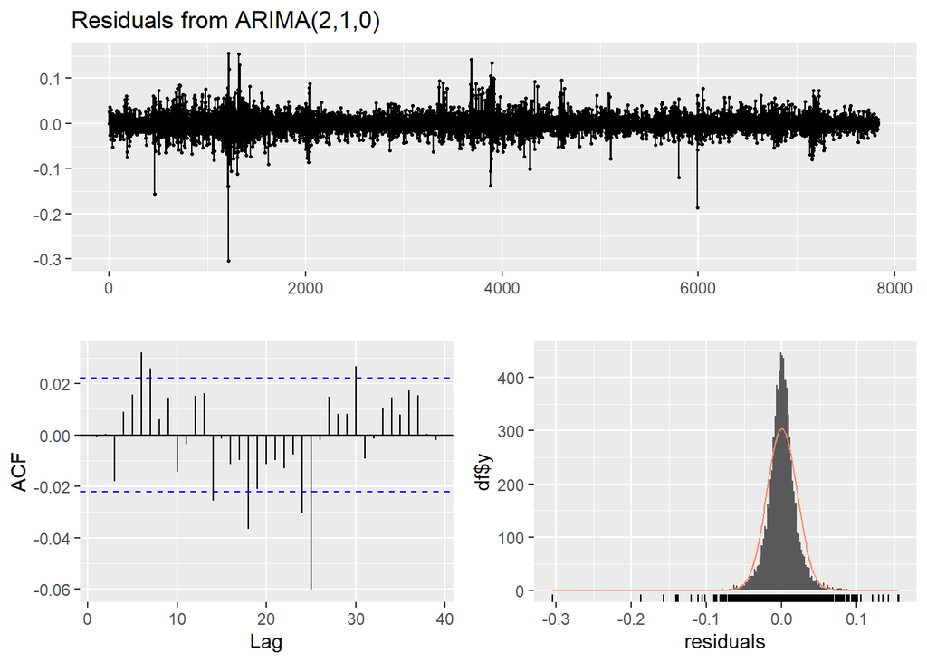

```
##
##  Ljung-Box test
##
## data:  Residuals from ARIMA(2,1,0)
## Q* = 22.007, df = 8, p-value = 0.004903
##
## Model df: 2.   Total lags used: 10
```

```r
arfc_ftm4 <- auto.arima(train_ftm, lambda = 0, stepwise = FALSE)
checkresiduals(arfc_ftm4)
```

Let’s see what tbats gives ups

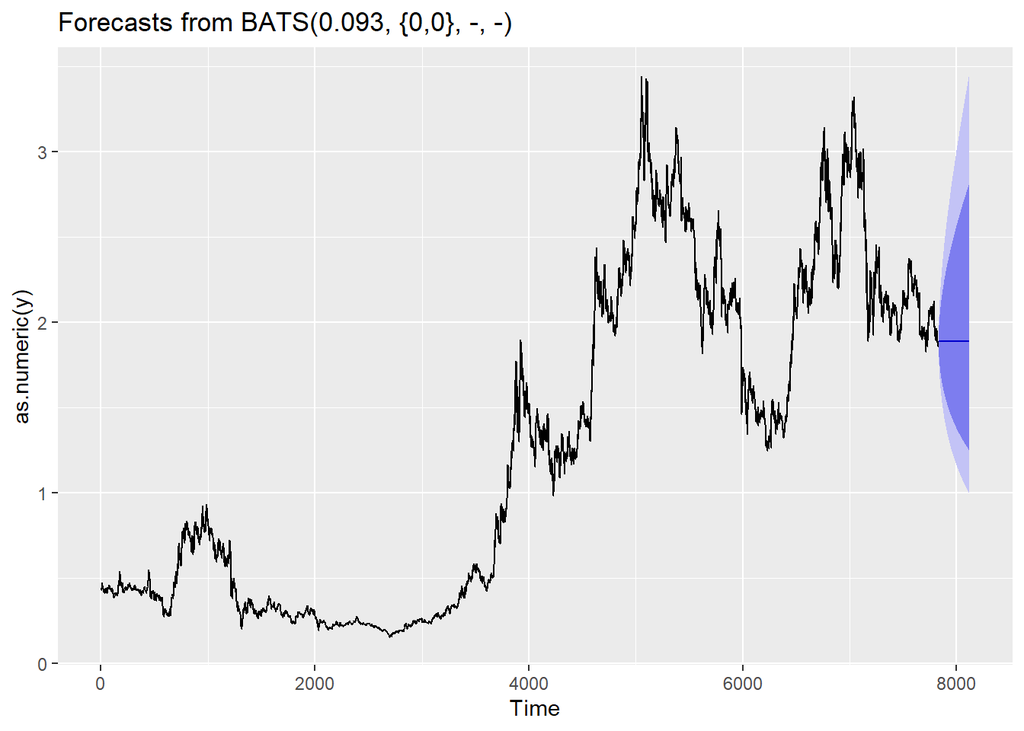

```r
train_ftm2 <- ts(train_ftm)
tbat_ftm <- tbats(train_ftm2)
tbat_ftm %>% forecast(h = test.length) %>% autoplot()
```

All of this basically sucks… What if we try looking at this in the form of returns instead of price?

```r
ftm_returns <- ftm_price %>%
  select(price)
```

```r
ftm_returns <-  ftm_returns[-1,] / ftm_returns[-8118,] - 1

train_ret <- ftm_returns %>%
  slice_head(n = length(ftm_returns$price) - test.length + 1)
test_ret <- ftm_returns %>%
  slice_tail(n = test.length - 1)

train_time <- ftm_price %>%
  slice_head(n = length(ftm_price$timestamp) - test.length + 1) %>%
  select(timestamp)
test_time <- ftm_price %>%
  slice_tail(n = test.length - 1) %>%
  select(timestamp)

train_time <- train_time[-1,]
```

```r
train_ret <- as.xts(train_ret[,1], order.by = train_time$timestamp)
test_ret <- as.xts(test_ret[,1], order.by = test_time$timestamp)
```

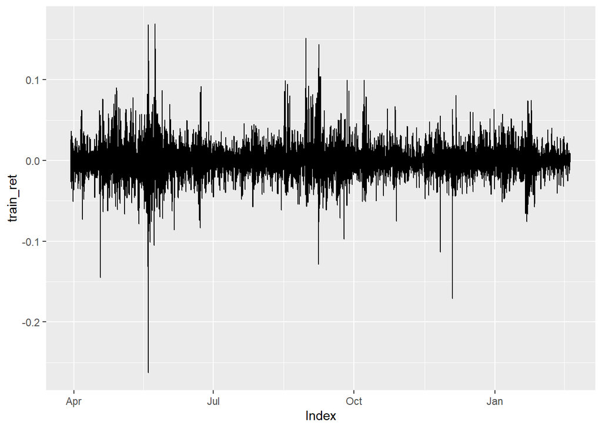

```r
autoplot(train_ret)
```

```r
Box.test(train_ret, lag = 24, fitdf = 0, type = "Lj")
```

```
##
##  Box-Ljung test
##
## data:  train_ret
## X-squared = 61.278, df = 24, p-value = 4.208e-05
```

```r
Box.test(train_ret, lag = 1, fitdf = 0, type = "Lj")
```

```
##
##  Box-Ljung test
##
## data:  train_ret
## X-squared = 0.78305, df = 1, p-value = 0.3762
```

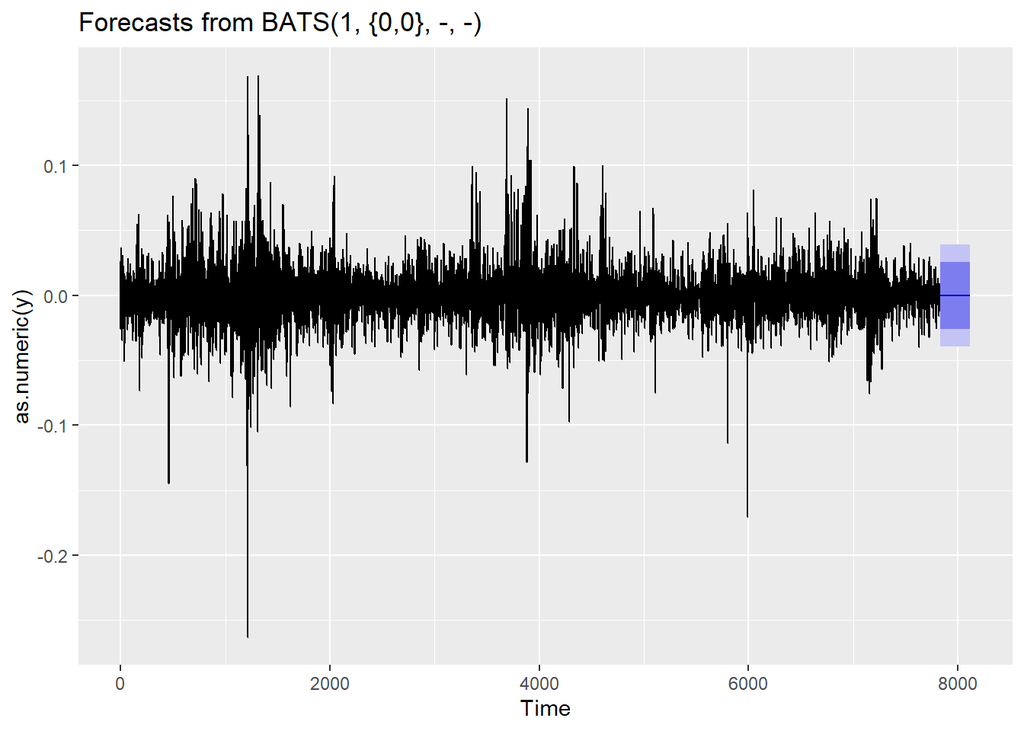

```r
train_ret2 <- ts(train_ret)
tbat_ret <- tbats(train_ret2)
tbat_ret %>% forecast(h = test.length) %>% autoplot()
```

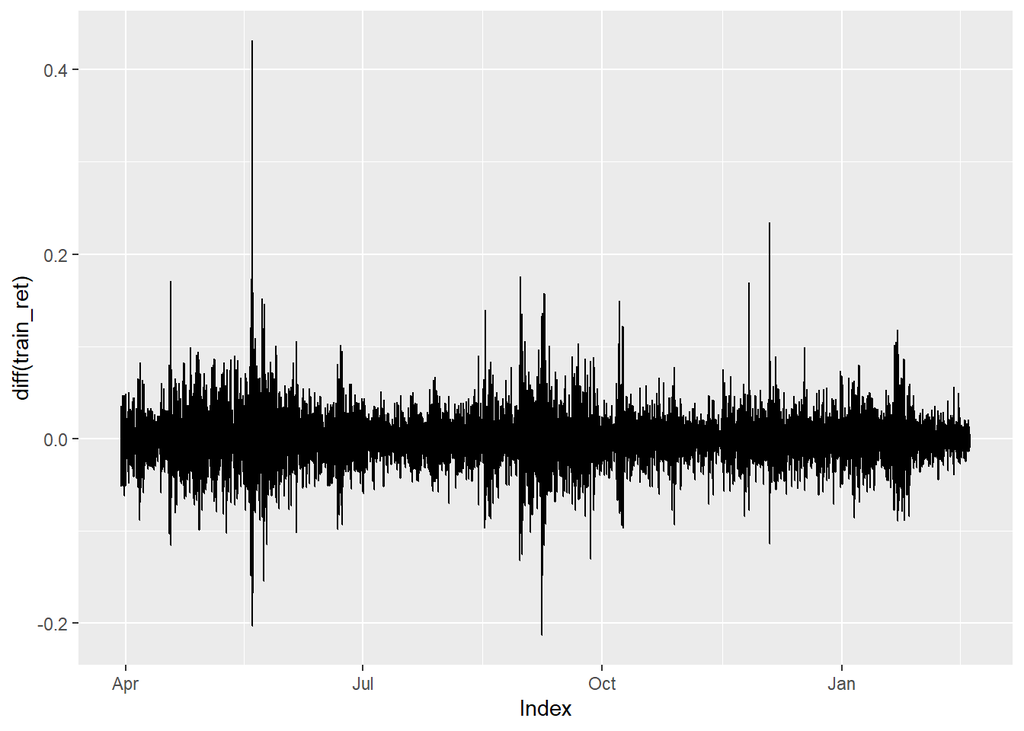

```r
autoplot(diff(train_ret))
```

```r
Box.test(diff(train_ret), lag = 1, fitdf = 0, type = "Lj")
```

```
##
##  Box-Ljung test
##
## data:  diff(train_ret)
## X-squared = 1824, df = 1, p-value < 2.2e-16
```

```r
Box.test(train_ret, lag = 24, fitdf = 0, type = "Lj")
```

```
##
##  Box-Ljung test
##
## data:  train_ret
## X-squared = 61.278, df = 24, p-value = 4.208e-05
```

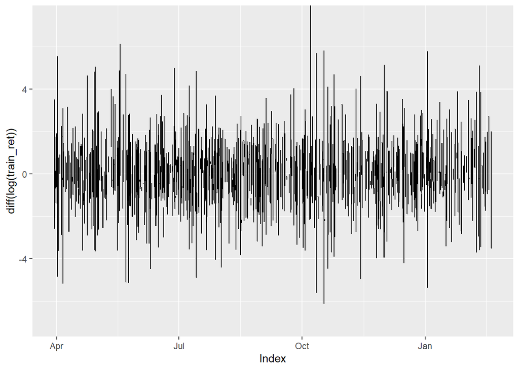

```r
autoplot(diff(log(train_ret)))
```

```r
diff_log_train <- diff(log(train_ret))
Box.test(diff_log_train, lag = 1, fitdf = 0, type = "Lj")
```

```
##
##  Box-Ljung test
##
## data:  diff_log_train
## X-squared = NaN, df = 1, p-value = NA
```

We’re at our limit just using price data and we don’t have much useful.. Let’s start looking at twitter data Import data

```r
# read in csv file of tweets
rawish.data <- read.csv('influencerdata_clean.csv')
tweets <- rawish.data
```

```r
tweets$created_at <- as_datetime(tweets$created_at, tz = "UTC")
tweets$quoted_created_at <- as_datetime(tweets$quoted_created_at, tz = "UTC")
tweets$retweet_created_at <- as_datetime(tweets$retweet_created_at, tz = "UTC")
tweets$account_created_at <- as_datetime(tweets$account_created_at, tz = "UTC")
```

Clean hashtags

```r
# common artifacts that remain after cleaning
other.words <- c("rt", "amp","htt")

# remove all urls
tweets$hashtags <- gsub("(s?)(f|ht)tp(s?)://\\S+\\b", "", tweets$hashtags)


# clean data
tweets$hashtags <- tweets$hashtags %>%
  removeNumbers() %>%
  tolower() %>%
  iconv(from = 'UTF-8', to = 'ASCII//TRANSLIT') %>% #Remove accents, foreign language items
  removeWords(stopwords("SMART")) %>%
  removeWords(other.words) %>%
  stemDocument() %>%
  stripWhitespace()

tweets$hashtags[tweets$hashtags == "NA"] <- NA
```

Clean symbols

```r
# common artifacts that remain after cleaning
other.words <- c("rt", "amp","htt")

# remove all urls
tweets$symbols <- gsub("(s?)(f|ht)tp(s?)://\\S+\\b", "", tweets$symbols)


# clean data
tweets$symbols <- tweets$symbols %>%
  removeNumbers() %>%
  tolower() %>%
  iconv(from = 'UTF-8', to = 'ASCII//TRANSLIT') %>% #Remove accents, foreign language items
  removeWords(stopwords("SMART")) %>%
  removeWords(other.words) %>%
  stemDocument() %>%
  stripWhitespace()

tweets$symbols[tweets$symbols == "NA"] <- NA
```

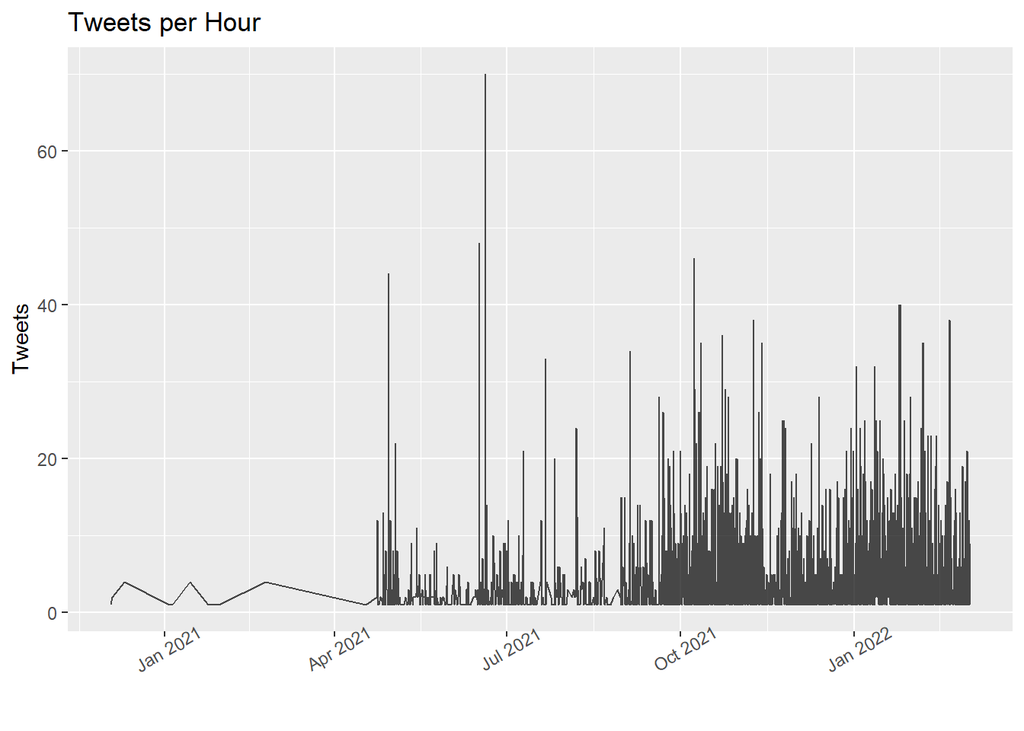

```r
ftm <- tweets %>%
  filter(symbols == "ftm") %>%
  mutate(hr = round_date(created_at, unit = "hour"))

ftm_summary <- ftm %>% count(hr)

ftm_summary %>%
  ggplot() +
  geom_line(aes(x = hr, y = n), alpha = .7) + # change alpha for readability
  theme(axis.text.x = element_text(angle = 30)) + # make x-axis more readable
  ggtitle("Tweets per Hour") +
  xlab("") +
  ylab("Tweets")
```

We don’t have price data until 4/1, let’s filter the tweets to then

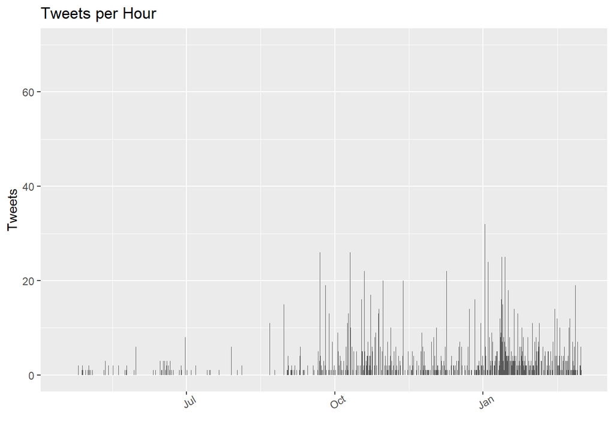

```r
ftm <- ftm %>%
  filter(created_at >= ftm.start.date)

ftm_summary <- ftm %>% count(hr)

ftm_summary %>%
  ggplot() +
  geom_col(aes(x = hr, y = n)) +
  theme(axis.text.x = element_text(angle = 30)) + # make x-axis more readable
  ggtitle("Tweets per Hour") +
  xlab("") +
  ylab("Tweets")
```

```r
ftm_price <-  ftm_price %>%
  mutate(hr = round_date(timestamp, unit = "hour"))
```

```r
#Merge the two tables
ftm_simple <- ftm_price %>%
  select(hr, price) %>%
  left_join(ftm_summary, by = c("hr" = "hr"))

# change nas to 0s
ftm_simple <- ftm_simple %>% mutate(n = ifelse(is.na(n), 0, n)) %>%
  rename(tweets = n)
```

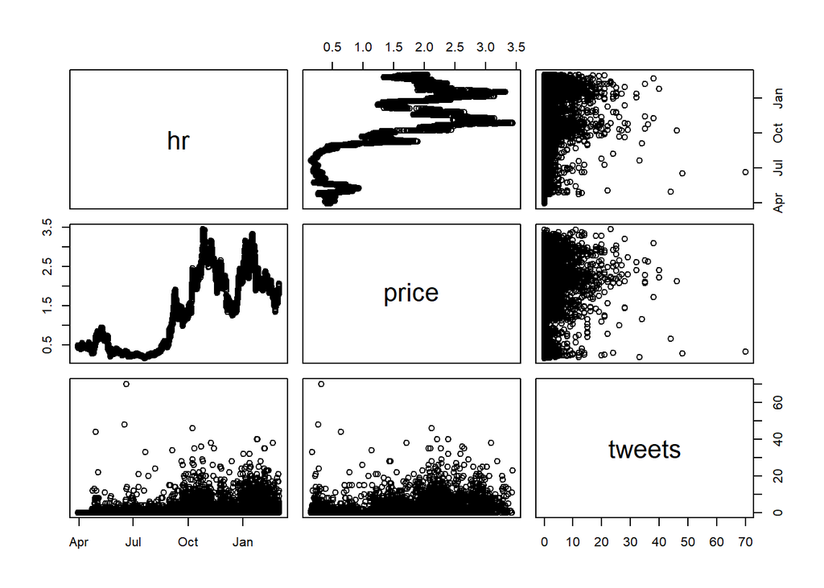

```r
pairs(ftm_simple)
```

That’s a mess

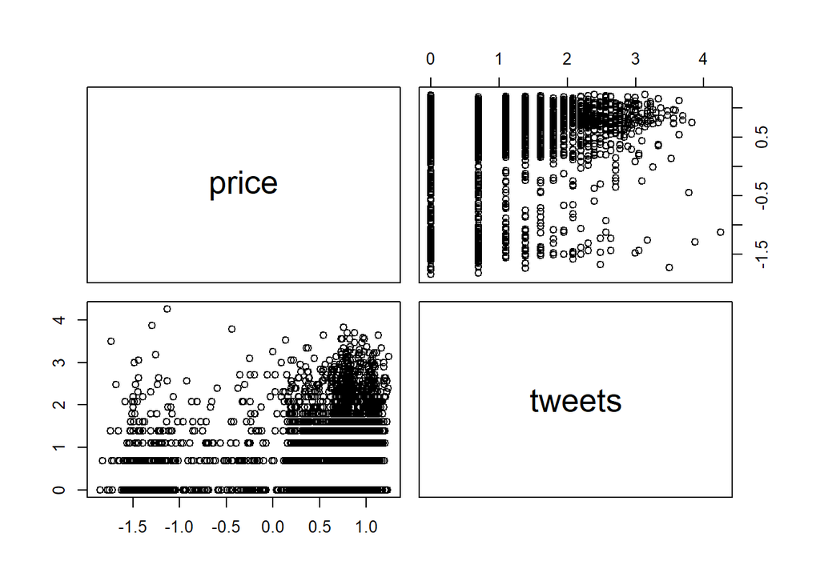

```r
ftm_price_tweets <- ftm_simple %>%
  select(-hr)
log_ftm <- log(ftm_price_tweets)
pairs(log_ftm)
```

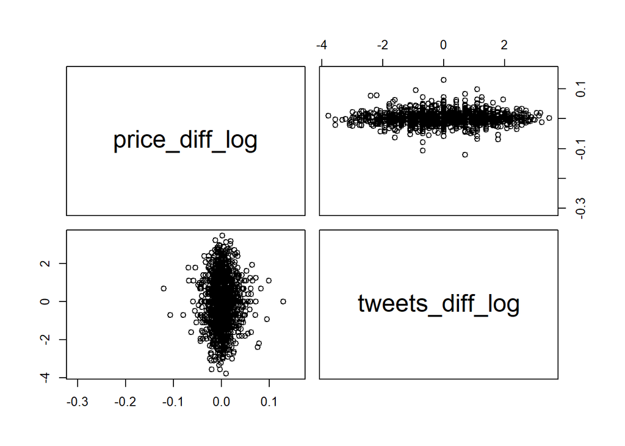

```r
price_diff_log <- diff(log_ftm$price)
tweets_diff_log <- diff(log_ftm$tweets)
diff_log_ftm <- cbind(price_diff_log, tweets_diff_log)
pairs(diff_log_ftm)
```

This might kinda be something?

```r
train_sftm <- ftm_simple %>%
  slice_head(n = length(ftm_simple$hr) - test.length)
test_sftm <- ftm_simple %>%
  slice_tail(n = test.length)
train_sftm <- as.xts(train_sftm[,2:3], order.by = train_sftm$hr)
test_sftm <- as.xts(test_sftm[,2:3], order.by = test_sftm$hr)
```

```r
autoplot(train_sftm, facets = TRUE)
```

[output not shown]

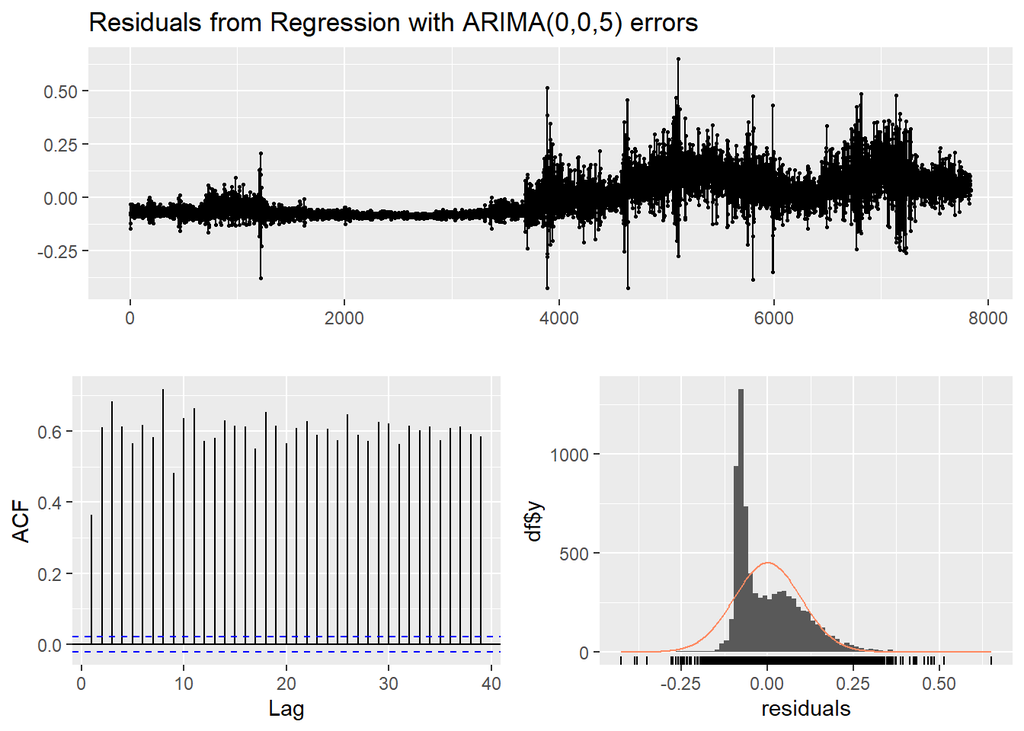

```
##
##  Ljung-Box test
##
## data:  Residuals from Regression with ARIMA(0,0,5) errors
## Q* = 27765, df = 5, p-value < 2.2e-16
##
## Model df: 5.   Total lags used: 10
```

```r
train_sftm2 <- ts(train_sftm)
test_sftm2 <- ts(test_sftm)
fit <- auto.arima(train_sftm2[,"price"], xreg = train_sftm2[,"tweets"], stationary = TRUE)
checkresiduals(fit)
```

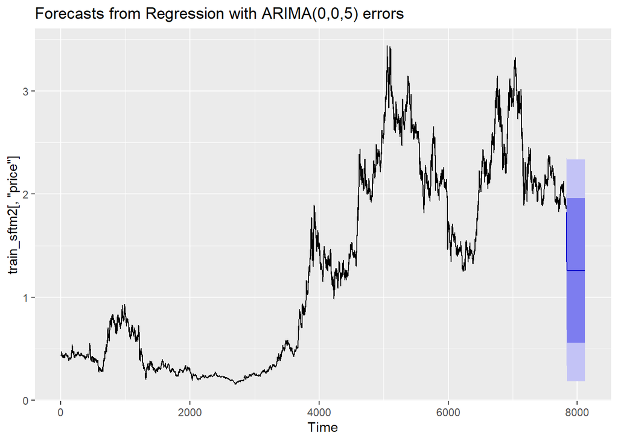

```r
fit %>% forecast(xreg = test_sftm2[,"tweets"]) %>% autoplot()
```

This looks better… What if we limit our data by a lot. 200-day and 50 day moving averages are popular Since we’re looking at hourly data, and lifecycles in crypto are so short, let’s use 50 day as the cut-off

```r
ftm_ssimple <- ftm_simple %>%
  slice_tail(n = 24*50 + test.length) %>%
  slice_head(n = 24*50)

train <- ftm_ssimple
test <- ftm_simple %>%
  slice_tail(n = test.length)
```